# HW4-Predictive regression modeling with R

misken

February 9, 2018

## Step 1 - Familiarize yourself with the data and the assignment

In this assignment you'll build some predictive regression models with R on a dataset containing inpatient discharges from hospitals in New York.

The version of this data that we'll be using is from a Kaggle dataset. See https://www.kaggle.com/jonasalmeida/2015-deidentified-ny-inpatient-discharge-sparcs. Unfortunately, the column metadata wasn't posted. However, since this is a publicly available dataset, we can visit the source at https://health.data.ny.gov/Health/Hospital-Inpatient-Discharges-SPARCS-De-Identified/82xm-y6g8.

If you scroll down on that page you'll find descriptions of the columns (click the little Show All link to display the entire list).

Most of the fields are self-explanatory. You'll notice that there are several sets of diagnosis and procedure codes. A few definitions are helpful.

### DRG - Diagnosis Related Groups

DRGs are a coding system developed in the 1980s that form the basis of how hospitals are reimbursed from Medicare (US Govt) or private insurers. After a patient is discharged from the hospital, a program known as a *DRG grouper* uses information such as diagnosis and procedure codes (ICD-9-CM) to assign a DRG to the patient. A full list of the over 900 DRGs can be found at:

https://www.cms.gov/Research-Statistics-Data-and-Systems/Statistics-Trends-and-Reports/MedicareFeeforSvcPartsAB/downloads/DRGdesc08.pdf

In that list you'll see that MDC (Medical Diagnostic Category) is simply a grouping of DRGs.

### CCS - Clinical Classification System

The [CCS](https://www.hcup-us.ahrq.gov/toolssoftware/ccs/ccs.jsp) system was developed by the [Agency for Healthcare Research and Quality (AHRQ)](https://www.ahrq.gov/) to provide a classification system better suited to healthcare research. There are CCS diagnosis codes and CCS procedure codes. From their website:

> The Clinical Classifications Software (CCS) for ICD-9-CM is a diagnosis and procedure categorization scheme that can be employed in many types of projects analyzing data on diagnoses and procedures. CCS is based on the International Classification of Diseases, 9th Revision, Clinical Modification (ICD-9-CM), a uniform and standardized coding system. The ICD-9-CM's multitude of codes - over 14,000 diagnosis codes and 3,900 procedure codes - are collapsed into a smaller number of clinically meaningful categories that are sometimes more useful for presenting descriptive statistics than are individual ICD-9-CM codes.

As we did in class, you'll be creating an R Markdown document to do the analysis as well as to document the steps you did (and answer some questions I'll throw at you).

You'll notice a few "Hacker Extra" tasks thrown in. These are for those of you who want to go a little above and beyond and attempt some more challenging tasks.

## Step 2 - Create a new R Markdown document

Save this file as a new R Markdown document and name it something that includes your last name in the filename. Save it into the same folder as this file.

## Step 3 - Create project and load data

Create an R Studio project in the current folder (the one containing this file). You'll notice that there is a folder named **data**. Inside of it you'll find the data file for this assignment:

- **ipd_resp.RData**

The full dataset contains over two million records and is available as a CSV file from Kaggle. I did a little data filtering and cleaning to create a subset to use for this regression assignment. Specifically, I did the following:

- used dplyr to filter records so that we were just working with `APR MDC Code` == 4. These are patients having respiratory related diagnoses.
- a bunch of fields were read in as `chr` and I changed them to factors using `as.factor`.
- There were some fields we don't need and they were dropped.
- Just as in HW1, I cleaned up the charges and costs fields that got interpreted as `chr` because of the leading dollar sign. Now they are numeric.
- Modified some field names to make them easier to work with.

See the data prep script for all the details. You do **NOT** need to run the data prep script. I'm just including it so you can see a typical data prep script.

### Load the data

```r
load("./data/ipd_resp.RData")
#str(ipd_resp)
```

## Step 4 - Partition into training and test sets

Just run this chunk to create training and test datasets. This way we'll all be working with the same datasets. Notice that the test set is 30% of the full dataset.

```r
set.seed(1828)
sample_size <- ceiling(0.30 * nrow(ipd_resp))
testrecs <- sample(nrow(ipd_resp),sample_size)
ipd_test <- ipd_resp[testrecs,]
ipd_train <- ipd_resp[-testrecs,]  # Negative in front of vector means "not in"
rm(ipd_resp) # No sense keeping a copy of the entire dataset around
```

## Step 5 - EDA on training data

Now start with some EDA on the training dataset`ipd_train`. The test data will only get used after building models and want to compare their predictive abilities.

You'll notice that `ipd_train` contains a few numeric fields and many factors (categorical data). You are free to use any of these fields in your regression models to predict `Total_Charges`.

Start by using things like ggplot2 and dplyr to explore the training dataset. You can use other packages as well. Your goal is to gain a general understanding of the variables and perhaps uncover some useful relationships that you can use in your regression models.

**NOTE: In the data prep phase I made sure there were no NA values in the data frames that we are using for this assignment. So, no need to worry about that.**

```r
library(dplyr)
```

```r
library(ggplot2)
library(caret)
library(boot)
summary(ipd_train)
```

```
##      Health_Service_Area  Hospital_County   Facility_Id
##  New York City :59355    Manhattan:17112   1169   :  3769
##  Long Island   :18906    Kings    :14286   1464   :  2655
##  Hudson Valley :14989    Bronx    :13883   1172   :  2517
##  Capital/Adiron:11629    Queens   :10931   1178   :  2341
##  Central NY    :10770    Suffolk  : 9603   1458   :  2091
##  Western NY    :10456    Nassau   : 9303   413    :  2013
##  (Other)       :11215    (Other)  :62202   (Other):121934
##                                                         Facility_Name
##  Montefiore Medical Center - Henry & Lucy Moses Div            :  3769
##  New York Presbyterian Hospital - Columbia Presbyterian Center :  2655
##  Lincoln Medical & Mental Health Center                        :  2517
##  Bronx-Lebanon Hospital Center - Concourse Division            :  2341
##  New York Presbyterian Hospital - New York Weill Cornell Center:  2091
##  Good Samaritan Hospital Medical Center                        :  2013
##  (Other)                                                       :121934
##        Age_Group        ZipCode      Gender
##  0 to 17    :18955   112    :16184   F:72465
##  18 to 29   : 4410   104    :15118   M:64855
##  30 to 49   :13174   117    :10422   U:    0
##  50 to 69   :44726   100    : 8879
##  70 or Older:56055   113    : 6190
##                      115    : 4771
##                      (Other):75756
##                      Race                   Ethnicity
##  Black/African American:26759   Multi-ethnic     :   533
##  Multi-racial          : 1248   Not Span/Hispanic:114997
##  Other Race            :28283   Spanish/Hispanic : 16107
##  White                 :81030   Unknown          :  5683
##
##
##
##  Length_of_Stay        Type_of_Admission
##  Min.   :  1.000   Elective     :  7833
##  1st Qu.:  2.000   Emergency    :123327
##  Median :  4.000   Newborn      :    15
##  Mean   :  5.591   Not Available:    56
##  3rd Qu.:  7.000   Trauma       :   391
##  Max.   :119.000   Urgent       :  5698
##
```

[output cut: 41 more lines]

```
##  Extreme :14310               Extreme : 9920
##  Major   :46752               Major   :36936
##  Minor   :23375               Minor   :50734
##  Moderate:52883               Moderate:39730
##  unknown :    0
##
##
##                  Payment_Typology_1 Total_Charges      Total_Costs
##  Medicare                 :72837    Min.   :      1   Min.   :     0.6
##  Medicaid                 :34848    1st Qu.:  13190   1st Qu.:  5283.6
##  Private Health Insurance :12315    Median :  24485   Median :  8998.8
##  Blue Cross/Blue Shield   :10478    Mean   :  41551   Mean   : 15527.7
##  Self-Pay                 : 3150    3rd Qu.:  46436   3rd Qu.: 16499.2
##  Managed Care, Unspecified: 1292    Max.   :2691248   Max.   :689872.8
##  (Other)                  : 2400
```

Now, it's your turn ...

```r
head(ipd_train)
```

```
## # A tibble: 6 x 25
##   Health_Service_A… Hospital_County Facility_Id Facility_Name    Age_Group
##   <fct>             <fct>           <fct>       <fct>            <ord>
## 1 Western NY        Cattaraugus     66          Olean General H… 50 to 69
## 2 Western NY        Erie            207         Buffalo General… 50 to 69
## 3 Western NY        Erie            207         Buffalo General… 30 to 49
## 4 Western NY        Erie            208         Women And Child… 0 to 17
## 5 Western NY        Erie            208         Women And Child… 0 to 17
## 6 Western NY        Erie            208         Women And Child… 0 to 17
## # ... with 20 more variables: ZipCode <fct>, Gender <fct>, Race <fct>,
## #   Ethnicity <fct>, Length_of_Stay <int>, Type_of_Admission <fct>,
## #   Patient_Disposition <fct>, CCS_Dx_Code <fct>, CCS_Dx_Desc <fct>,
## #   CCS_Proc_Code <fct>, CCS_Proc_Desc <fct>, APR_DRG_Code <fct>,
## #   APR_DRG_Desc <fct>, APR_MDC_Code <fct>, APR_MDC_Desc <fct>,
## #   APR_Severity_of_Illness_Desc <fct>, APR_Risk_of_Mortality <fct>,
## #   Payment_Typology_1 <fct>, Total_Charges <dbl>, Total_Costs <dbl>
```

```r
str(ipd_train)
```

```
## Classes 'tbl_df', 'tbl' and 'data.frame':    137320 obs. of  25 variables:
##  $ Health_Service_Area         : Factor w/ 8 levels "Capital/Adiron",..: 8 8 8 8 8 8 8 8 8 8 ...
##  $ Hospital_County             : Factor w/ 57 levels "Albany","Allegany",..: 5 15 15 15 15 15 15 15 15 15 ...
##  $ Facility_Id                 : Factor w/ 213 levels "1","2","4","5",..: 11 30 30 31 31 31 31 31 31 31 ...
##  $ Facility_Name               : Factor w/ 215 levels "Abortion Record - Facility Name Redacted",..: 134 20 20 212 212 212 212 212 212 212 ...
##  $ Age_Group                   : Ord.factor w/ 5 levels "0 to 17"<"18 to 29"<..: 4 4 3 1 1 1 1 1 1 1 ...
##  $ ZipCode                     : Factor w/ 50 levels "100","101","103",..: 47 42 42 40 41 40 50 43 41 42 ...
##  $ Gender                      : Factor w/ 3 levels "F","M","U": 1 2 1 1 2 2 2 1 1 1 ...
##  $ Race                        : Factor w/ 4 levels "Black/African American",..: 4 4 3 4 4 4 3 4 4 1 ...
##  $ Ethnicity                   : Factor w/ 4 levels "Multi-ethnic",..: 2 2 3 2 2 2 2 2 2 2 ...
##  $ Length_of_Stay              : int  4 1 1 4 1 1 2 1 3 1 ...
##  $ Type_of_Admission           : Factor w/ 6 levels "Elective","Emergency",..: 2 2 2 6 2 2 2 2 2 2 ...
##  $ Patient_Disposition         : Factor w/ 19 levels "Another Type Not Listed",..: 8 8 8 8 8 8 8 8 8 8 ...
##  $ CCS_Dx_Code                 : Factor w/ 263 levels "1","2","3","4",..: 117 92 117 117 114 114 117 117 117 117 ...
##  $ CCS_Dx_Desc                 : Factor w/ 263 levels "Abdominal hernia",..: 20 230 20 20 6 6 20 20 20 20 ...
##  $ CCS_Proc_Code               : Factor w/ 232 levels "0","1","2","3",..: 1 1 1 1 1 1 1 1 1 1 ...
##  $ CCS_Proc_Desc               : Factor w/ 232 levels "ABDOMINAL PARACENTESIS",..: 122 122 122 122 122 122 122 122 122 122 ...
##  $ APR_DRG_Code                : Factor w/ 316 levels "1","2","3","4",..: 62 55 62 62 59 59 62 62 62 62 ...
##  $ APR_DRG_Desc                : Factor w/ 316 levels "Abdominal pain",..: 17 271 17 17 25 25 17 17 17 17 ...
##  $ APR_MDC_Code                : Factor w/ 26 levels "0","1","2","3",..: 5 5 5 5 5 5 5 5 5 5 ...
##  $ APR_MDC_Desc                : Factor w/ 26 levels "Alcohol/Drug Use and Alcohol/Drug Induced Organic Mental Disorders",..: 13 13 13 13 13 13 13 13 13 13 ...
##  $ APR_Severity_of_Illness_Desc: Factor w/ 5 levels "Extreme","Major",..: 3 3 4 4 4 3 4 4 4 4 ...
##  $ APR_Risk_of_Mortality       : Factor w/ 4 levels "Extreme","Major",..: 3 3 3 3 3 3 3 3 3 3 ...
##  $ Payment_Typology_1          : Factor w/ 10 levels "Blue Cross/Blue Shield",..: 6 5 5 8 5 5 5 5 8 5 ...
##  $ Total_Charges               : num  11304 7512 6709 21882 4584 ...
##  $ Total_Costs                 : num  4584 2746 2561 13889 2743 ...
```

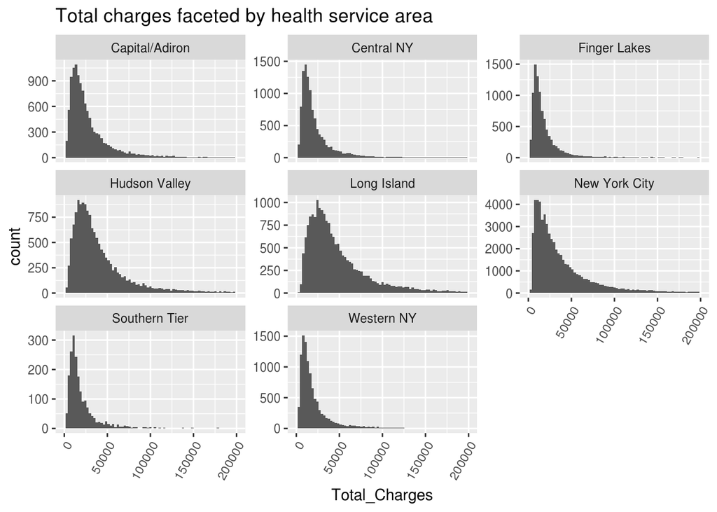

```r
ggplot(ipd_train) + geom_histogram(aes(x=Total_Charges), bins = 75) + facet_wrap(~Health_Service_Area, scales = "free_y") + xlim(0, 200000)+ theme(axis.text.x = element_text(angle = 60, hjust = 1)) + ggtitle("Total charges faceted by health service area")
```

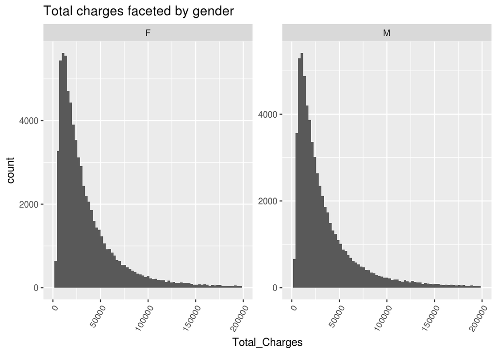

```r
ggplot(ipd_train) + geom_histogram(aes(x=Total_Charges), bins = 75) + facet_wrap(~Gender, scales = "free_y") + xlim(0, 200000)+ theme(axis.text.x = element_text(angle = 60, hjust = 1)) + ggtitle("Total charges faceted by gender")
```

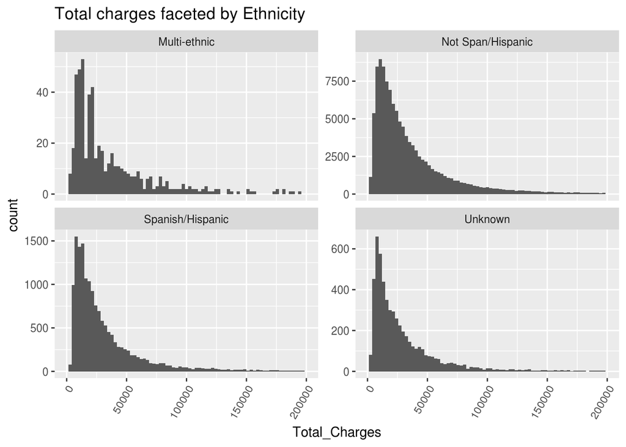

```r
ggplot(ipd_train) + geom_histogram(aes(x=Total_Charges), bins = 75) + facet_wrap(~Ethnicity, scales = "free_y") + xlim(0, 200000)+ theme(axis.text.x = element_text(angle = 60, hjust = 1)) + ggtitle("Total charges faceted by Ethnicity")
```

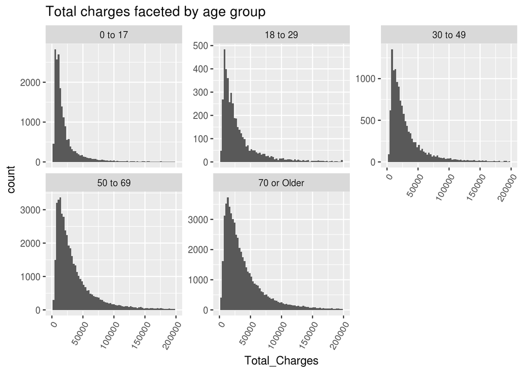

```r
ggplot(ipd_train) + geom_histogram(aes(x=Total_Charges), bins = 75) + facet_wrap(~Age_Group, scales = "free_y") + xlim(0, 200000)+ theme(axis.text.x = element_text(angle = 60, hjust = 1)) + ggtitle("Total charges faceted by age group")
```

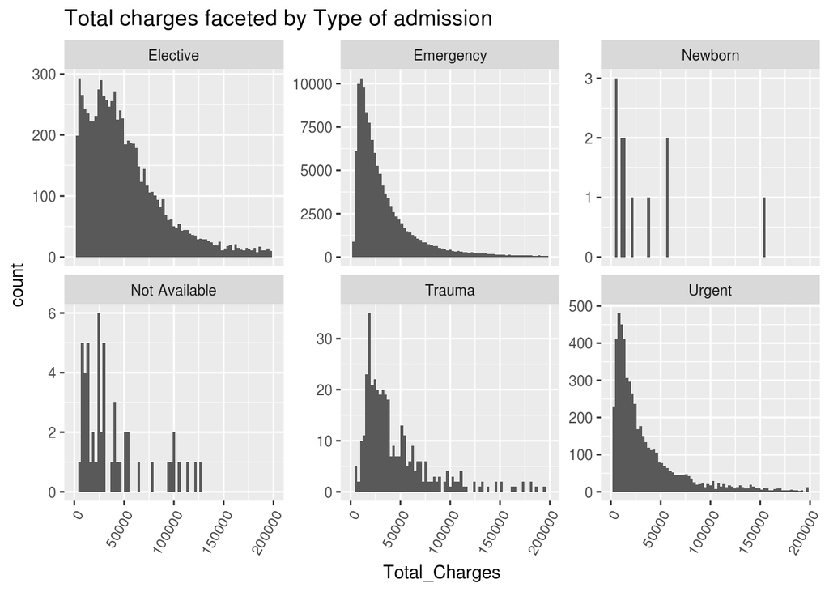

```r
ggplot(ipd_train) + geom_histogram(aes(x=Total_Charges), bins = 75) + facet_wrap(~Type_of_Admission, scales = "free_y") + xlim(0, 200000)+ theme(axis.text.x = element_text(angle = 60, hjust = 1)) + ggtitle("Total charges faceted by Type of admission")
```

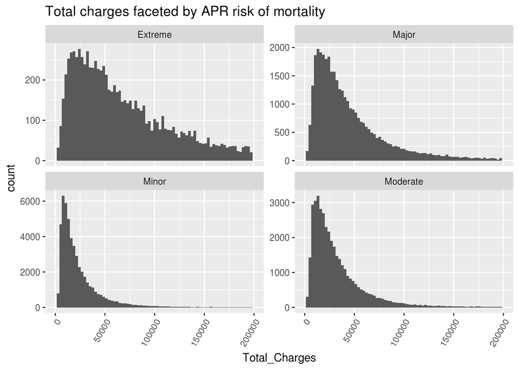

```r
ggplot(ipd_train) + geom_histogram(aes(x=Total_Charges), bins = 75) + facet_wrap(~APR_Risk_of_Mortality, scales = "free_y") + xlim(0, 200000)+ theme(axis.text.x = element_text(angle = 60, hjust = 1)) + ggtitle("Total charges faceted by APR risk of mortality")
```

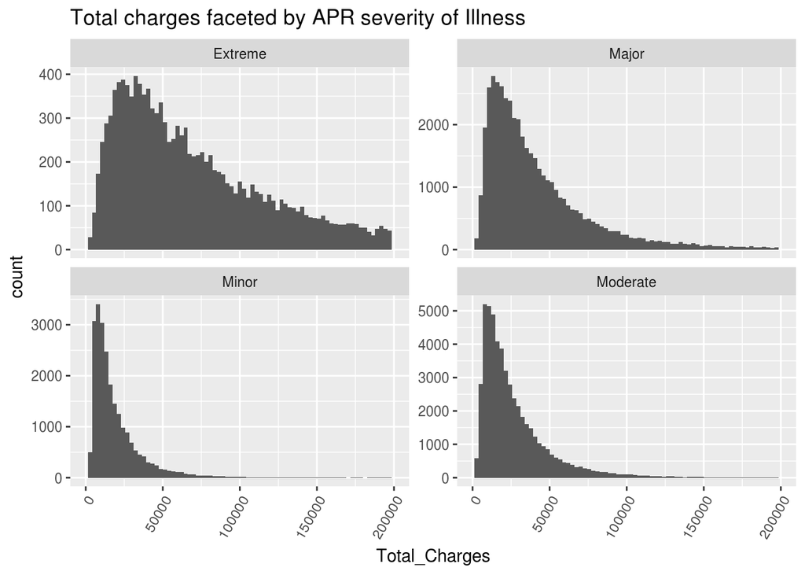

```r
ggplot(ipd_train) + geom_histogram(aes(x=Total_Charges), bins = 75) + facet_wrap(~APR_Severity_of_Illness_Desc, scales = "free_y") + xlim(0, 200000)+ theme(axis.text.x = element_text(angle = 60, hjust = 1)) + ggtitle("Total charges faceted by APR severity of Illness")
```

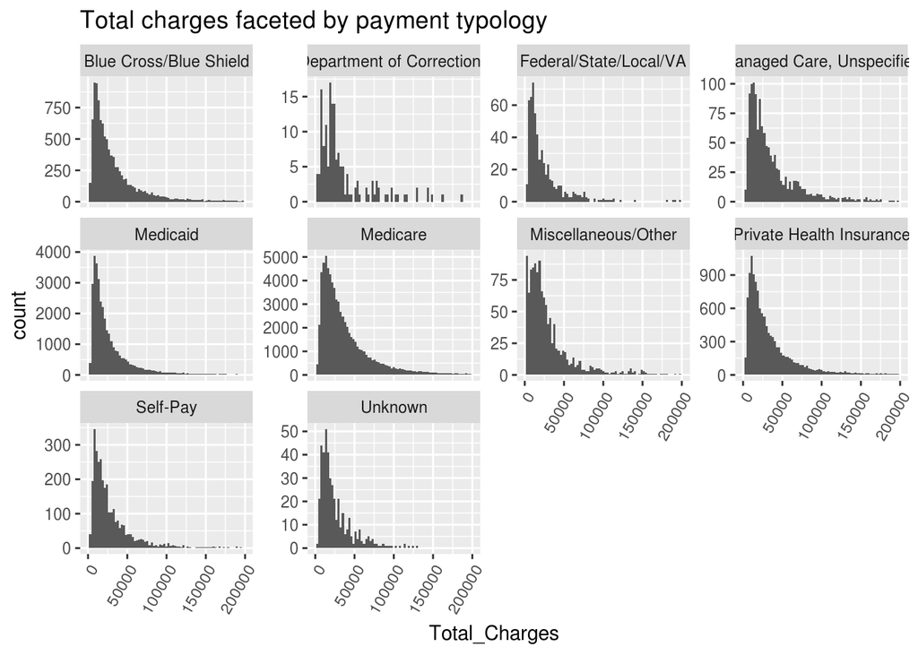

```r
ggplot(ipd_train) + geom_histogram(aes(x=Total_Charges), bins = 75) + facet_wrap(~Payment_Typology_1, scales = "free_y") + xlim(0, 200000)+ theme(axis.text.x = element_text(angle = 60, hjust = 1)) + ggtitle("Total charges faceted by payment typology")
```

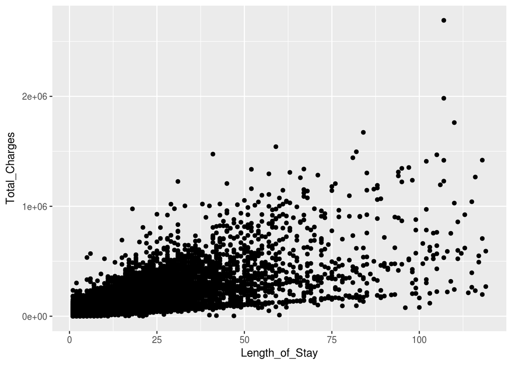

```r
ggplot(ipd_train) + geom_point(aes(x=Length_of_Stay, y=Total_Charges))
```

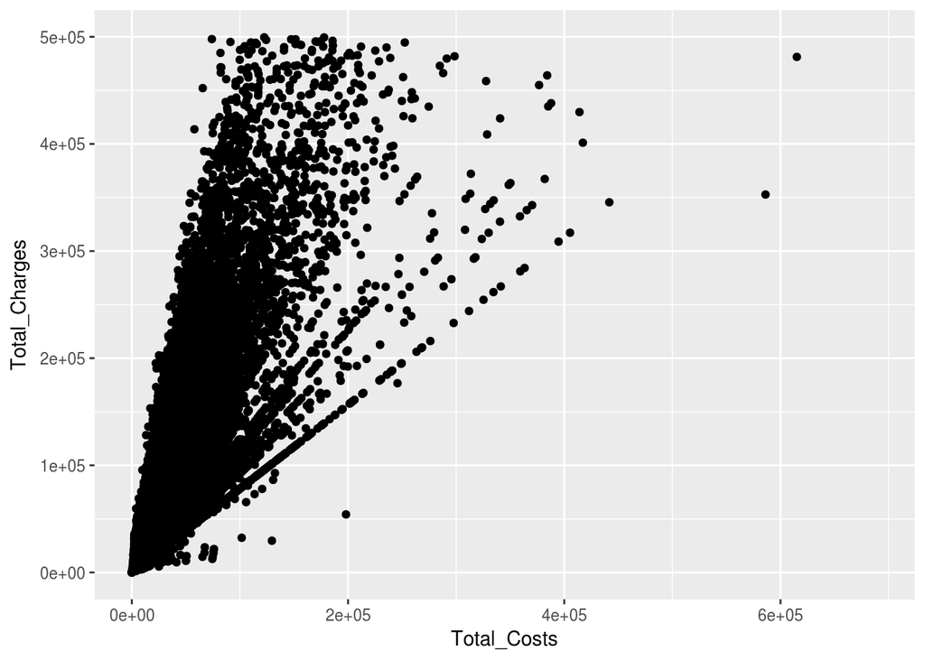

```r
ggplot(ipd_train) + geom_point(aes(x=Total_Costs, y=Total_Charges)) + ylim(0, 500000)
```

I thought there would be a stronger relation between length of stay and total charges, this was rather surprising.

Wow you were right, the relation between cost and total charges is pretty out of whack. Total charges increases far faster than total costs.

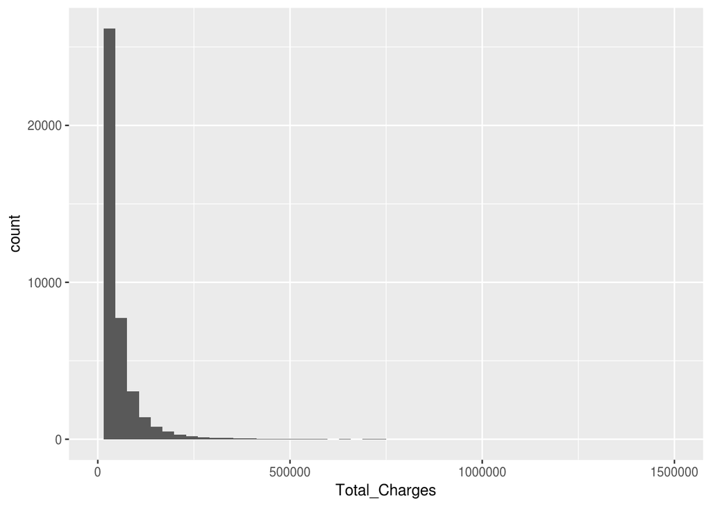

```r
ggplot(ipd_test) + geom_histogram(aes(x=Total_Charges), bins=50) + xlim(0, 1500000)
```

## Step 6 - Building and evaluation of predictive models

Now that you know a little more about the data, it's time to start building a few predictive models for `Total_Charges`. The error metric that we will use to evaluate the models (both for fit and for predictions) is **median absolute deviation** (MAD). This is nothing more than the median of the absolute value of the residuals for a fitted model.

**QUESTION:** What might be an advantage of using median absolute deviation instead of mean absolute deviation?

Obviously we want models with lower MAD values. Our ultimate goal is to create a model that predicts well on the test dataset, `ipd_test`.

### Null model

It's always a good idea to start out with what we call the *null model*. This is the simplest possible model and one that other models better be able to beat. For this regression problem, the null model is simply a regression model that just has a y-intercept. If you remember some of your statistics, you won't be surprised that the best fit value for the y-intercept in this case is the mean of the response variable, `Total_Charges`.

```r
charges_lm0 <- lm(Total_Charges ~ 1, data = ipd_train)
summary(charges_lm0)
```

```
##
## Call:
## lm(formula = Total_Charges ~ 1, data = ipd_train)
##
## Residuals:
##     Min      1Q  Median      3Q     Max
##  -41550  -28361  -17067    4885 2649697
##
## Coefficients:
##             Estimate Std. Error t value Pr(>|t|)
## (Intercept)    41551        172   241.5   <2e-16 ***
## ---
## Signif. codes:  0 '***' 0.001 '**' 0.01 '*' 0.05 '.' 0.1 ' ' 1
##
## Residual standard error: 63750 on 137319 degrees of freedom
```

```r
# Compute the MAD value
median(abs(charges_lm0$residuals))
```

```
## [1] 24376.3
```

It's not hard to create regression models with smaller MAD values than this. :)

Just to give you a benchmark, I built a model on the training set that had a MAD value of 7270.340. Again, this is just the median of the absolute values of the residuals of the fitted model. Later when I used this model on the test data, I got a MAD of ... well, I'll tell you a little later.

### Model building

Using the information you've gained from reading about the data and doing some EDA, build several regression models and compute the MAD from each. Summarize your results in terms of which model or models appear to fit well.

```r
mattsmodel_lm1 <- (lm(Total_Charges ~ Age_Group + Gender + Length_of_Stay + APR_Risk_of_Mortality + Health_Service_Area, data = ipd_train))
summary(mattsmodel_lm1)
```

```
##
## Call:
## lm(formula = Total_Charges ~ Age_Group + Gender + Length_of_Stay +
##     APR_Risk_of_Mortality + Health_Service_Area, data = ipd_train)
##
## Residuals:
##     Min      1Q  Median      3Q     Max
## -644842  -11024   -2566    8382 1907748
##
## Coefficients:
##                                   Estimate Std. Error t value Pr(>|t|)
## (Intercept)                       15123.91     580.84  26.038  < 2e-16 ***
## Age_Group.L                       -6199.78     310.91 -19.941  < 2e-16 ***
## Age_Group.Q                       -4858.53     289.86 -16.762  < 2e-16 ***
## Age_Group.C                         957.34     385.99   2.480 0.013133 *
## Age_Group^4                       -1936.06     367.79  -5.264 1.41e-07 ***
## GenderM                             746.53     202.98   3.678 0.000235 ***
## Length_of_Stay                     7005.21      15.85 441.842  < 2e-16 ***
## APR_Risk_of_MortalityMajor       -19698.66     430.50 -45.758  < 2e-16 ***
## APR_Risk_of_MortalityMinor       -25847.19     465.25 -55.556  < 2e-16 ***
## APR_Risk_of_MortalityModerate    -22223.46     438.59 -50.670  < 2e-16 ***
## Health_Service_AreaCentral NY     -4886.16     499.27  -9.787  < 2e-16 ***
## Health_Service_AreaFinger Lakes   -8684.15     520.49 -16.685  < 2e-16 ***
## Health_Service_AreaHudson Valley  13282.43     461.83  28.761  < 2e-16 ***
## Health_Service_AreaLong Island    22263.72     440.38  50.556  < 2e-16 ***
## Health_Service_AreaNew York City  17444.09     381.45  45.731  < 2e-16 ***
## Health_Service_AreaSouthern Tier  -7422.37     906.33  -8.189 2.65e-16 ***
## Health_Service_AreaWestern NY     -5606.63     503.39 -11.138  < 2e-16 ***
## ---
## Signif. codes:  0 '***' 0.001 '**' 0.01 '*' 0.05 '.' 0.1 ' ' 1
##
## Residual standard error: 37330 on 137303 degrees of freedom
## Multiple R-squared:  0.6571, Adjusted R-squared:  0.6571
## F-statistic: 1.645e+04 on 16 and 137303 DF,  p-value: < 2.2e-16
```

```r
median(abs(mattsmodel_lm1$residuals))
```

```
## [1] 9945.761
```

```r
mattsmodel_lm2 <- (lm(Total_Charges ~ Total_Costs + Payment_Typology_1 + Patient_Disposition + Length_of_Stay + Hospital_County, data = ipd_train))
summary(mattsmodel_lm2)
```

```
##
## Call:
## lm(formula = Total_Charges ~ Total_Costs + Payment_Typology_1 +
##     Patient_Disposition + Length_of_Stay + Hospital_County, data = ipd_train)
##
## Residuals:
##     Min      1Q  Median      3Q     Max
## -788519   -7995    -538    6468 1409609
##
## Coefficients:
##                                                            Estimate
## (Intercept)                                               5.361e+03
## Total_Costs                                               1.604e+00
## Payment_Typology_1Department of Corrections              -1.697e+04
## Payment_Typology_1Federal/State/Local/VA                 -2.453e+03
## Payment_Typology_1Managed Care, Unspecified              -2.406e+03
## Payment_Typology_1Medicaid                               -5.279e+03
## Payment_Typology_1Medicare                               -2.522e+03
## Payment_Typology_1Miscellaneous/Other                    -2.128e+03
## Payment_Typology_1Private Health Insurance               -1.607e+02
## Payment_Typology_1Self-Pay                               -2.366e+04
## Payment_Typology_1Unknown                                -2.158e+03
## Patient_DispositionCancer Center or Children's Hospital   4.686e+04
## Patient_DispositionCourt/Law Enforcement                  1.540e+04
## Patient_DispositionCritical Access Hospital               4.656e+03
## Patient_DispositionExpired                                7.591e+03
## Patient_DispositionFacility w/ Custodial/Supportive Care  8.799e+02
## Patient_DispositionFederal Health Care Facility           5.342e+02
## Patient_DispositionHome or Self Care                      2.371e+03
## Patient_DispositionHome w/ Home Health Services           4.296e+03
## Patient_DispositionHosp Basd Medicare Approved Swing Bed -4.238e+03
## Patient_DispositionHospice - Home                         2.081e+03
## Patient_DispositionHospice - Medical Facility             3.536e+03
## Patient_DispositionInpatient Rehabilitation Facility      9.102e+03
## Patient_DispositionLeft Against Medical Advice            1.085e+03
## Patient_DispositionMedicaid Cert Nursing Facility        -9.818e+02
## Patient_DispositionMedicare Cert Long Term Care Hospital  2.819e+03
## Patient_DispositionPsychiatric Hospital or Unit of Hosp   2.094e+03
## Patient_DispositionShort-term Hospital                    3.135e+02
## Patient_DispositionSkilled Nursing Home                   4.239e+03
```

[output cut: 309 more lines]

```
## Hospital_CountySuffolk                                   ***
## Hospital_CountySullivan
## Hospital_CountyTompkins                                  ***
## Hospital_CountyUlster
## Hospital_CountyWarren                                    ***
## Hospital_CountyWayne                                     ***
## Hospital_CountyWestchester
## Hospital_CountyWyoming                                   ***
## Hospital_CountyYates                                     ***
## ---
## Signif. codes:  0 '***' 0.001 '**' 0.01 '*' 0.05 '.' 0.1 ' ' 1
##
## Residual standard error: 28490 on 137234 degrees of freedom
## Multiple R-squared:  0.8004, Adjusted R-squared:  0.8003
## F-statistic:  6473 on 85 and 137234 DF,  p-value: < 2.2e-16
```

```r
median(abs(mattsmodel_lm2$residuals))
```

```
## [1] 7212.167
```

```r
mattsmodel_lm3 <- (lm(Total_Charges ~ Total_Costs + Hospital_County + Length_of_Stay, data = ipd_train))
summary(mattsmodel_lm3)
```

```
##
## Call:
## lm(formula = Total_Charges ~ Total_Costs + Hospital_County +
##     Length_of_Stay, data = ipd_train)
##
## Residuals:
##     Min      1Q  Median      3Q     Max
## -781733   -7723    -297    6288 1410464
##
## Coefficients:
##                              Estimate Std. Error t value Pr(>|t|)
## (Intercept)                 5.170e+03  4.827e+02  10.711  < 2e-16 ***
## Total_Costs                 1.591e+00  5.256e-03 302.614  < 2e-16 ***
## Hospital_CountyAllegany    -1.876e+04  1.828e+03 -10.259  < 2e-16 ***
## Hospital_CountyBronx       -5.895e+03  5.375e+02 -10.968  < 2e-16 ***
## Hospital_CountyBroome      -1.150e+04  8.259e+02 -13.921  < 2e-16 ***
## Hospital_CountyCattaraugus -1.568e+04  1.347e+03 -11.640  < 2e-16 ***
## Hospital_CountyCayuga      -1.242e+04  1.320e+03  -9.405  < 2e-16 ***
## Hospital_CountyChautauqua  -1.976e+04  1.116e+03 -17.705  < 2e-16 ***
## Hospital_CountyChemung     -1.092e+04  1.029e+03 -10.611  < 2e-16 ***
## Hospital_CountyChenango    -6.323e+03  2.298e+03  -2.752 0.005929 **
## Hospital_CountyClinton     -9.448e+03  1.095e+03  -8.628  < 2e-16 ***
## Hospital_CountyColumbia    -1.229e+04  1.354e+03  -9.073  < 2e-16 ***
## Hospital_CountyCortland    -1.810e+04  1.483e+03 -12.200  < 2e-16 ***
## Hospital_CountyDelaware    -1.591e+04  2.398e+03  -6.632 3.31e-11 ***
## Hospital_CountyDutchess     4.951e+03  7.537e+02   6.568 5.12e-11 ***
## Hospital_CountyErie        -1.106e+04  5.918e+02 -18.691  < 2e-16 ***
## Hospital_CountyEssex       -1.953e+04  2.786e+03  -7.010 2.39e-12 ***
## Hospital_CountyFranklin    -1.920e+04  1.765e+03 -10.878  < 2e-16 ***
## Hospital_CountyFulton      -7.113e+03  1.688e+03  -4.214 2.52e-05 ***
## Hospital_CountyGenesee     -1.163e+04  2.020e+03  -5.759 8.50e-09 ***
## Hospital_CountyHerkimer    -1.701e+04  2.304e+03  -7.380 1.60e-13 ***
## Hospital_CountyJefferson   -1.103e+04  1.231e+03  -8.960  < 2e-16 ***
## Hospital_CountyKings       -1.017e+04  5.365e+02 -18.947  < 2e-16 ***
## Hospital_CountyLewis       -2.092e+04  2.589e+03  -8.083 6.36e-16 ***
## Hospital_CountyLivingston  -1.523e+04  1.973e+03  -7.720 1.17e-14 ***
## Hospital_CountyMadison     -1.191e+04  1.426e+03  -8.355  < 2e-16 ***
## Hospital_CountyManhattan    2.398e+03  5.306e+02   4.520 6.20e-06 ***
## Hospital_CountyMonroe      -1.644e+04  6.148e+02 -26.741  < 2e-16 ***
## Hospital_CountyMontgomery  -1.498e+04  1.398e+03 -10.719  < 2e-16 ***
```

[output cut: 21 more lines]

```
## Hospital_CountySullivan    -2.488e+03  1.713e+03  -1.452 0.146496
## Hospital_CountyTompkins    -2.323e+04  1.671e+03 -13.900  < 2e-16 ***
## Hospital_CountyUlster      -8.510e+02  1.063e+03  -0.801 0.423188
## Hospital_CountyWarren      -8.924e+03  9.632e+02  -9.265  < 2e-16 ***
## Hospital_CountyWayne       -9.773e+03  1.469e+03  -6.651 2.92e-11 ***
## Hospital_CountyWestchester  5.482e+02  6.036e+02   0.908 0.363710
## Hospital_CountyWyoming     -2.443e+04  1.865e+03 -13.105  < 2e-16 ***
## Hospital_CountyYates       -1.719e+04  3.158e+03  -5.442 5.28e-08 ***
## Length_of_Stay              2.696e+03  1.886e+01 142.898  < 2e-16 ***
## ---
## Signif. codes:  0 '***' 0.001 '**' 0.01 '*' 0.05 '.' 0.1 ' ' 1
##
## Residual standard error: 28780 on 137261 degrees of freedom
## Multiple R-squared:  0.7962, Adjusted R-squared:  0.7961
## F-statistic:  9248 on 58 and 137261 DF,  p-value: < 2.2e-16
```

```r
median(abs(mattsmodel_lm3$residuals))
```

```
## [1] 6959.464
```

```r
mattsmodel_lm4 <- (lm(Total_Charges ~ Total_Costs + Hospital_County + Length_of_Stay + Type_of_Admission + APR_Severity_of_Illness_Desc, data = ipd_train))
summary(mattsmodel_lm4)
```

```
##
## Call:
## lm(formula = Total_Charges ~ Total_Costs + Hospital_County +
##     Length_of_Stay + Type_of_Admission + APR_Severity_of_Illness_Desc,
##     data = ipd_train)
##
## Residuals:
##     Min      1Q  Median      3Q     Max
## -757681   -7911       3    6783 1435337
##
## Coefficients:
##                                        Estimate Std. Error t value
## (Intercept)                           2.182e+04  6.366e+02  34.274
## Total_Costs                           1.555e+00  5.267e-03 295.232
## Hospital_CountyAllegany              -1.768e+04  1.812e+03  -9.759
## Hospital_CountyBronx                 -3.879e+03  5.360e+02  -7.237
## Hospital_CountyBroome                -1.139e+04  8.195e+02 -13.902
## Hospital_CountyCattaraugus           -1.554e+04  1.335e+03 -11.641
## Hospital_CountyCayuga                -1.253e+04  1.309e+03  -9.577
## Hospital_CountyChautauqua            -1.874e+04  1.107e+03 -16.936
## Hospital_CountyChemung               -1.052e+04  1.023e+03 -10.282
## Hospital_CountyChenango              -4.597e+03  2.276e+03  -2.020
## Hospital_CountyClinton               -8.839e+03  1.088e+03  -8.123
## Hospital_CountyColumbia              -1.060e+04  1.343e+03  -7.894
## Hospital_CountyCortland              -1.702e+04  1.470e+03 -11.574
## Hospital_CountyDelaware              -1.374e+04  2.377e+03  -5.782
## Hospital_CountyDutchess               5.517e+03  7.477e+02   7.378
## Hospital_CountyErie                  -1.094e+04  5.876e+02 -18.615
## Hospital_CountyEssex                 -1.706e+04  2.760e+03  -6.184
## Hospital_CountyFranklin              -1.891e+04  1.748e+03 -10.820
## Hospital_CountyFulton                -6.008e+03  1.672e+03  -3.592
## Hospital_CountyGenesee               -1.067e+04  2.001e+03  -5.332
## Hospital_CountyHerkimer              -1.555e+04  2.285e+03  -6.806
## Hospital_CountyJefferson             -9.735e+03  1.221e+03  -7.974
## Hospital_CountyKings                 -8.577e+03  5.345e+02 -16.047
## Hospital_CountyLewis                 -1.952e+04  2.564e+03  -7.611
## Hospital_CountyLivingston            -1.300e+04  1.955e+03  -6.650
## Hospital_CountyMadison               -1.058e+04  1.413e+03  -7.490
## Hospital_CountyManhattan              3.230e+03  5.273e+02   6.126
## Hospital_CountyMonroe                -1.590e+04  6.105e+02 -26.044
```

[output cut: 98 more lines]

```
## Length_of_Stay                        < 2e-16 ***
## Type_of_AdmissionEmergency            < 2e-16 ***
## Type_of_AdmissionNewborn              < 2e-16 ***
## Type_of_AdmissionNot Available       0.240394
## Type_of_AdmissionTrauma              1.55e-05 ***
## Type_of_AdmissionUrgent              0.000719 ***
## APR_Severity_of_Illness_DescMajor     < 2e-16 ***
## APR_Severity_of_Illness_DescMinor     < 2e-16 ***
## APR_Severity_of_Illness_DescModerate  < 2e-16 ***
## ---
## Signif. codes:  0 '***' 0.001 '**' 0.01 '*' 0.05 '.' 0.1 ' ' 1
##
## Residual standard error: 28500 on 137253 degrees of freedom
## Multiple R-squared:  0.8002, Adjusted R-squared:  0.8001
## F-statistic:  8328 on 66 and 137253 DF,  p-value: < 2.2e-16
```

```r
median(abs(mattsmodel_lm4$residuals))
```

```
## [1] 7261.886
```

```r
mattsmodel_lm5 <- (lm(Total_Charges ~ Total_Costs + Length_of_Stay + Payment_Typology_1 + Age_Group + APR_DRG_Code, data = ipd_train))
summary(mattsmodel_lm5)
```

```
##
## Call:
## lm(formula = Total_Charges ~ Total_Costs + Length_of_Stay + Payment_Typology_1 +
##     Age_Group + APR_DRG_Code, data = ipd_train)
##
## Residuals:
##     Min      1Q  Median      3Q     Max
## -809336   -8899   -1266    7457 1438823
##
## Coefficients:
##                                               Estimate Std. Error t value
## (Intercept)                                  1.799e+05  4.495e+03  40.029
## Total_Costs                                  1.471e+00  5.490e-03 267.859
## Length_of_Stay                               2.596e+03  1.938e+01 133.972
## Payment_Typology_1Department of Corrections -1.169e+04  2.316e+03  -5.046
## Payment_Typology_1Federal/State/Local/VA    -5.457e+03  1.241e+03  -4.396
## Payment_Typology_1Managed Care, Unspecified -3.013e+03  8.576e+02  -3.513
## Payment_Typology_1Medicaid                  -4.462e+03  3.281e+02 -13.597
## Payment_Typology_1Medicare                  -1.118e+03  3.388e+02  -3.301
## Payment_Typology_1Miscellaneous/Other       -3.266e+03  8.993e+02  -3.632
## Payment_Typology_1Private Health Insurance   8.698e+02  3.862e+02   2.252
## Payment_Typology_1Self-Pay                  -2.282e+04  5.965e+02 -38.262
## Payment_Typology_1Unknown                   -9.028e+03  1.432e+03  -6.305
## Age_Group.L                                 -1.117e+03  3.025e+02  -3.691
## Age_Group.Q                                  5.909e+01  2.468e+02   0.239
## Age_Group.C                                  9.652e+02  3.076e+02   3.138
## Age_Group^4                                 -1.158e+02  2.883e+02  -0.402
## APR_DRG_Code3                               -1.656e+05  1.120e+04 -14.788
## APR_DRG_Code4                               -5.689e+04  4.923e+03 -11.557
## APR_DRG_Code5                               -1.193e+05  4.602e+03 -25.923
## APR_DRG_Code120                             -1.532e+05  4.496e+03 -34.065
## APR_DRG_Code121                             -1.587e+05  4.498e+03 -35.286
## APR_DRG_Code130                             -1.581e+05  4.492e+03 -35.207
## APR_DRG_Code131                             -1.684e+05  4.641e+03 -36.291
## APR_DRG_Code132                             -1.749e+05  4.788e+03 -36.536
## APR_DRG_Code133                             -1.743e+05  4.491e+03 -38.809
## APR_DRG_Code134                             -1.713e+05  4.497e+03 -38.091
## APR_DRG_Code135                             -1.707e+05  4.525e+03 -37.712
## APR_DRG_Code136                             -1.734e+05  4.505e+03 -38.495
## APR_DRG_Code137                             -1.742e+05  4.496e+03 -38.741
```

[output cut: 41 more lines]

```
## APR_DRG_Code139                              < 2e-16 ***
## APR_DRG_Code140                              < 2e-16 ***
## APR_DRG_Code141                              < 2e-16 ***
## APR_DRG_Code142                              < 2e-16 ***
## APR_DRG_Code143                              < 2e-16 ***
## APR_DRG_Code144                              < 2e-16 ***
## APR_DRG_Code950                              < 2e-16 ***
## APR_DRG_Code951                              < 2e-16 ***
## APR_DRG_Code952                              < 2e-16 ***
## ---
## Signif. codes:  0 '***' 0.001 '**' 0.01 '*' 0.05 '.' 0.1 ' ' 1
##
## Residual standard error: 29050 on 137281 degrees of freedom
## Multiple R-squared:  0.7924, Adjusted R-squared:  0.7923
## F-statistic: 1.379e+04 on 38 and 137281 DF,  p-value: < 2.2e-16
```

```r
median(abs(mattsmodel_lm5$residuals))
```

```
## [1] 8282.722
```

The Third model fits best when using MAD as the benchmark for goodness of fit. Sometimes simpler is better and the three predictors used in that model generally some up why hospital charges increase. The county where the hospital is located will impact the charges the patient/insurer faces by virtue of the economic landscape of that particular county. The longer the stay in the hospital the greater the charges will be to the patient/insurer. Lastly, the total costs the hospital faces will have a direct impact on the total charges the patient/insurer will see.

Identify your top 3 models in terms of lowest MAD values to use in the next part in which you'll use them to make predictions on the test dataset.

**HACKER EXTRA:** Use k-crossfold validation to select your top 3 models.

Found the following method in R for everyone ch 21.3

```r
mattsmodel_g1 <- glm(Total_Charges ~ Age_Group + Gender + Length_of_Stay + APR_Risk_of_Mortality + Health_Service_Area, data = ipd_train, family = gaussian(link = "identity"))
mattsmodel_CV1 <- cv.glm(ipd_train, mattsmodel_g1, K=10)

mattsmodel_g2 <- glm(Total_Charges ~ Total_Costs + Payment_Typology_1 + Patient_Disposition + Length_of_Stay + Hospital_County, data = ipd_train, family = gaussian(link = "identity"))
mattsmodel_CV2 <- cv.glm(ipd_train, mattsmodel_g2, K=10)

mattsmodel_g3 <- glm(Total_Charges ~ Total_Costs + Hospital_County + Length_of_Stay, data = ipd_train, family = gaussian(link = "identity"))
mattsmodel_CV3 <- cv.glm(ipd_train, mattsmodel_g3, K=10)

mattsmodel_g4 <- glm(Total_Charges ~ Total_Costs + Hospital_County + Length_of_Stay + Type_of_Admission + APR_Severity_of_Illness_Desc, data = ipd_train, family = gaussian(link = "identity"))
mattsmodel_CV4 <- cv.glm(ipd_train, mattsmodel_g4, K=10)

mattsmodel_g5 <- glm(Total_Charges ~ Total_Costs + Length_of_Stay + Payment_Typology_1 + Age_Group + APR_DRG_Code, data = ipd_train, family = gaussian(link = "identity"))
mattsmodel_CV5 <- cv.glm(ipd_train, mattsmodel_g5, K=10)

cvResults <- as.data.frame(rbind(mattsmodel_CV1$delta, mattsmodel_CV2$delta, mattsmodel_CV3$delta, mattsmodel_CV4$delta, mattsmodel_CV5$delta))

names(cvResults) <- c("Error", "Adjusted.Error")

cvResults$Model <- sprintf("model%s", 1:5)

cvResults
```

```
##        Error Adjusted.Error  Model
## 1 1395043619     1394949586 model1
## 2  812955689      812862017 model2
## 3  829626448      829541360 model3
## 4  814235236      814113550 model4
## 5  846182549      846052180 model5
```

#### Scatterplots of actual vs fitted values

For your top 3 models, create a scatter plot showing actual vs fitted values of `Total_Charges`. Remember, it's often nice to "gather up" your results into a data frame to facilitate plotting. See the notes on comparing competing regression models. Here's what one of my scatterplots looks like.

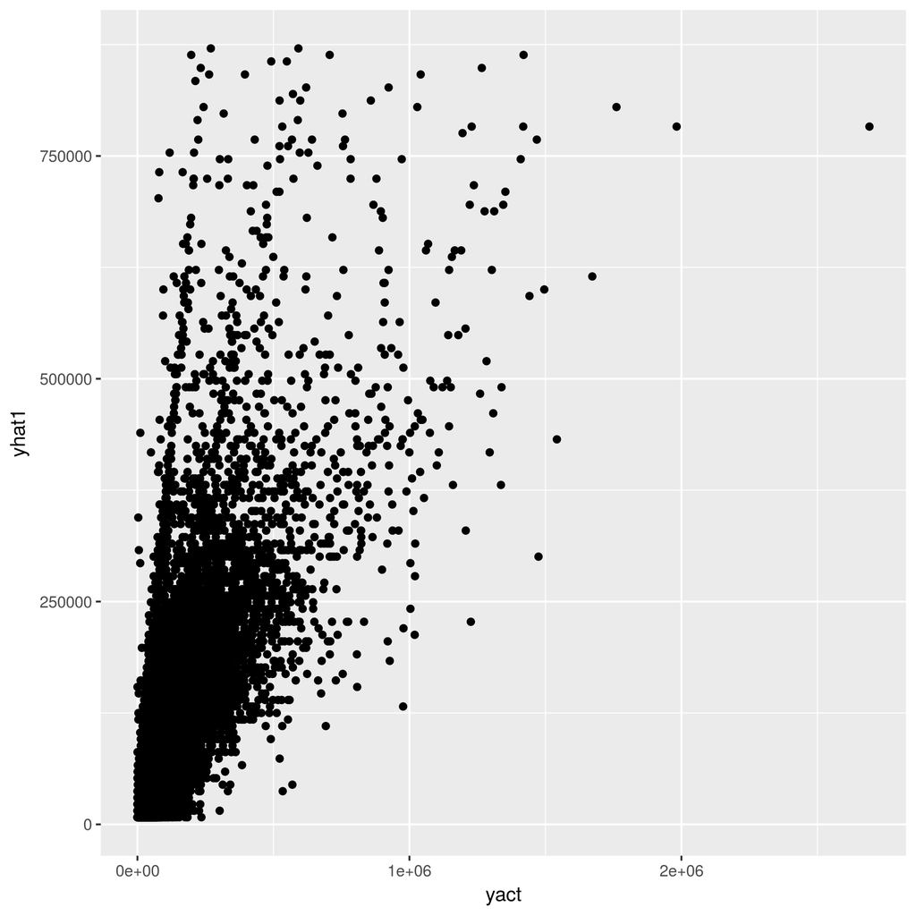

```r
head(fortify(mattsmodel_lm2))
```

```
##   Total_Charges Total_Costs       Payment_Typology_1 Patient_Disposition
## 1      11304.44     4584.11                 Medicare   Home or Self Care
## 3       7511.85     2745.50                 Medicaid   Home or Self Care
## 4       6708.54     2560.86                 Medicaid   Home or Self Care
## 5      21882.35    13888.95 Private Health Insurance   Home or Self Care
## 6       4583.54     2742.73                 Medicaid   Home or Self Care
## 8       7019.58     2234.07                 Medicaid   Home or Self Care
##   Length_of_Stay Hospital_County         .hat   .sigma      .cooksd
## 1              4     Cattaraugus 0.0019338527 28490.22 4.631356e-07
## 3              1            Erie 0.0001779598 28490.21 2.162182e-07
## 4              1            Erie 0.0001779339 28490.21 1.930254e-07
## 5              4            Erie 0.0002252214 28490.22 1.664184e-07
## 6              1            Erie 0.0001779594 28490.22 1.007020e-07
## 8              1            Erie 0.0001778938 28490.21 2.318061e-07
##     .fitted    .resid  .stdresid
## 1  7223.641  4080.799  0.1433743
## 3 -1695.854  9207.704  0.3232182
## 4 -1991.959  8700.499  0.3054137
## 5 29062.631 -7180.281 -0.2520554
## 6 -1700.296  6283.836  0.2205816
## 8 -2516.027  9535.607  0.3347285
```

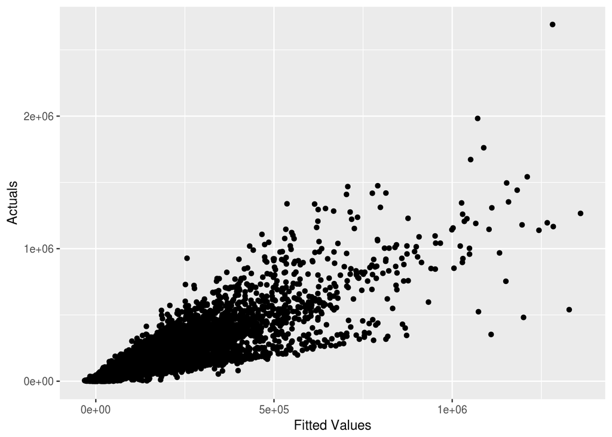

```r
h1 <- ggplot(aes(x=.fitted, y=ipd_train$Total_Charges), data = mattsmodel_lm2) + geom_point() + labs(x="Fitted Values", y="Actuals")
h1
```

```r
head(fortify(mattsmodel_lm3))
```

```
##   Total_Charges Total_Costs Hospital_County Length_of_Stay         .hat
## 1      11304.44     4584.11     Cattaraugus              4 0.0019158525
## 3       7511.85     2745.50            Erie              1 0.0001508516
## 4       6708.54     2560.86            Erie              1 0.0001508169
## 5      21882.35    13888.95            Erie              4 0.0001488098
## 6       4583.54     2742.73            Erie              1 0.0001508511
## 8       7019.58     2234.07            Erie              1 0.0001507612
##    .sigma      .cooksd    .fitted    .resid  .stdresid
## 1 28781.4 5.509121e-07  7562.7860  3741.654  0.1301277
## 3 28781.4 1.241352e-07  1171.0608  6340.789  0.2203260
## 4 28781.4 1.049592e-07   877.3658  5831.174  0.2026182
## 5 28781.4 7.924677e-08 26983.2487 -5100.899 -0.1772428
## 6 28781.4 3.604686e-08  1166.6548  3416.885  0.1187279
## 8 28781.4 1.369491e-07   357.5618  6662.018  0.2314878
```

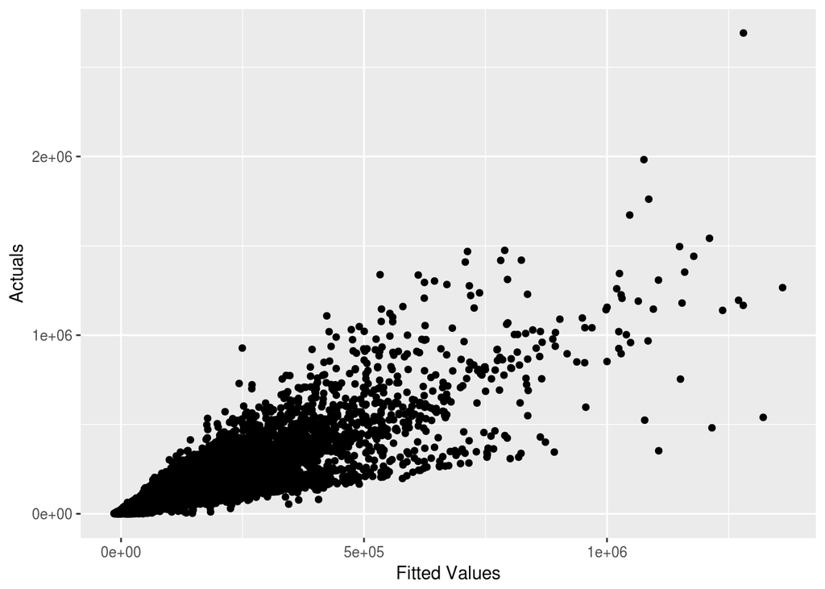

```r
h2 <- ggplot(aes(x=.fitted, y=ipd_train$Total_Charges), data = mattsmodel_lm3) + geom_point() + labs(x="Fitted Values", y="Actuals")
h2
```

```r
head(fortify(mattsmodel_lm4))
```

```
##   Total_Charges Total_Costs Hospital_County Length_of_Stay
## 1      11304.44     4584.11     Cattaraugus              4
## 3       7511.85     2745.50            Erie              1
## 4       6708.54     2560.86            Erie              1
## 5      21882.35    13888.95            Erie              4
## 6       4583.54     2742.73            Erie              1
## 8       7019.58     2234.07            Erie              1
##   Type_of_Admission APR_Severity_of_Illness_Desc         .hat   .sigma
## 1         Emergency                        Minor 0.0019637825 28501.71
## 3         Emergency                        Minor 0.0001952156 28501.71
## 4         Emergency                     Moderate 0.0001641936 28501.71
## 5            Urgent                     Moderate 0.0003318759 28501.71
## 6         Emergency                     Moderate 0.0001642361 28501.71
## 8         Emergency                        Minor 0.0001951219 28501.71
##        .cooksd    .fitted    .resid  .stdresid
## 1 2.228697e-06  3460.5403  7843.900  0.2754796
## 3 3.549388e-07 -2433.9905  9945.840  0.3489912
## 4 1.862154e-07 -1146.8051  7855.345  0.2756332
## 5 1.906676e-07 27472.3699 -5590.020 -0.1961625
## 6 8.957681e-08  -863.9818  5447.522  0.1911460
## 8 3.767170e-07 -3229.3076 10248.888  0.3596248
```

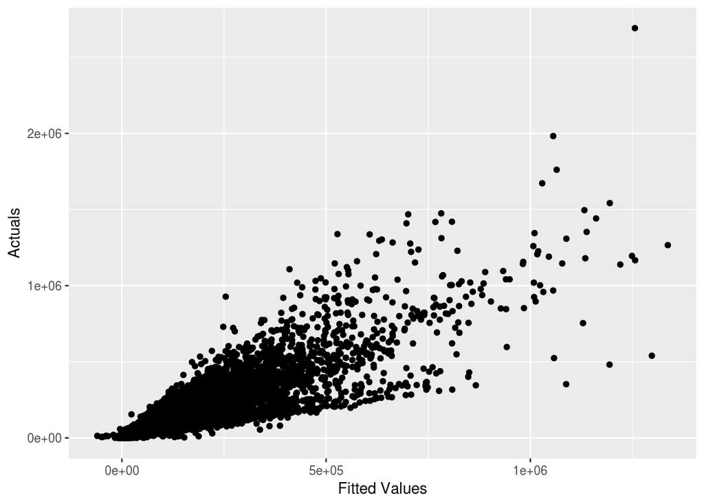

```r
h3 <- ggplot(aes(x=.fitted, y=ipd_train$Total_Charges), data = mattsmodel_lm4) + geom_point() + labs(x="Fitted Values", y="Actuals")
h3
```

#### Normality of residuals

Create a histogram of the residuals for your top 3 models. You may have to tweak the axes scales to make a nice histogram.

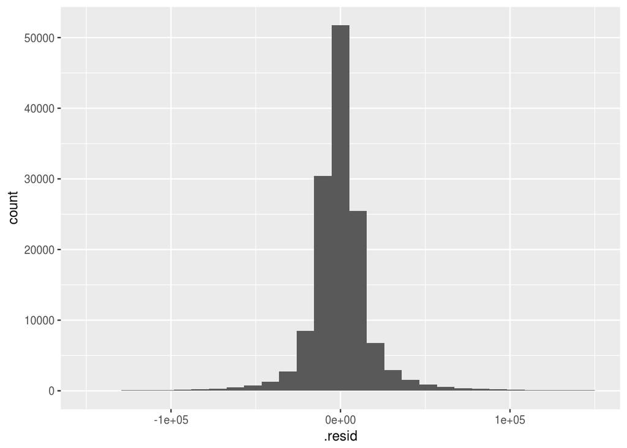

```r
ggplot(mattsmodel_lm2, aes(x=.resid)) + geom_histogram() + xlim(-150000, 150000)
```

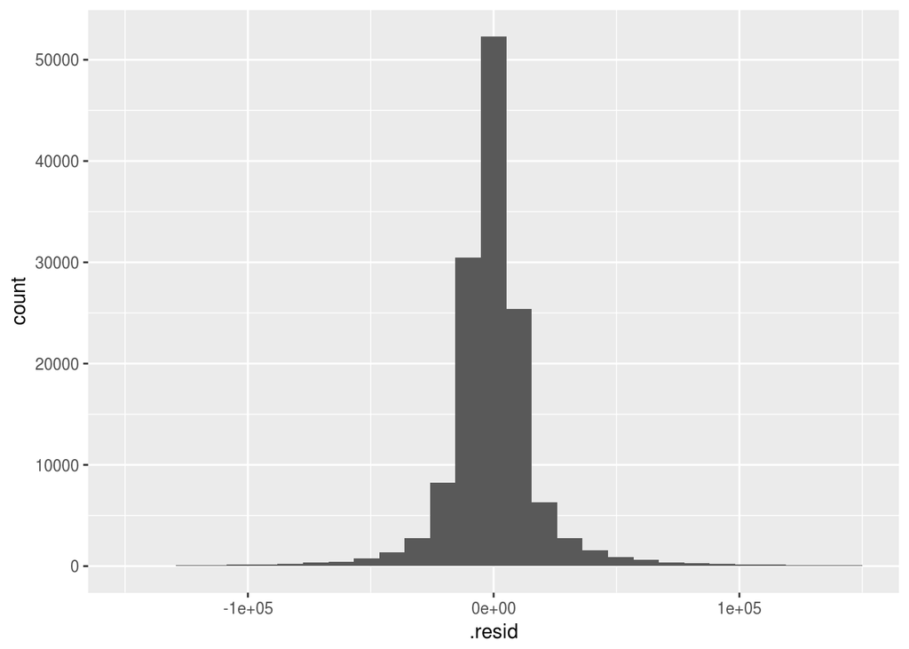

```r
ggplot(mattsmodel_lm3, aes(x=.resid)) + geom_histogram() + xlim(-150000, 150000)
```

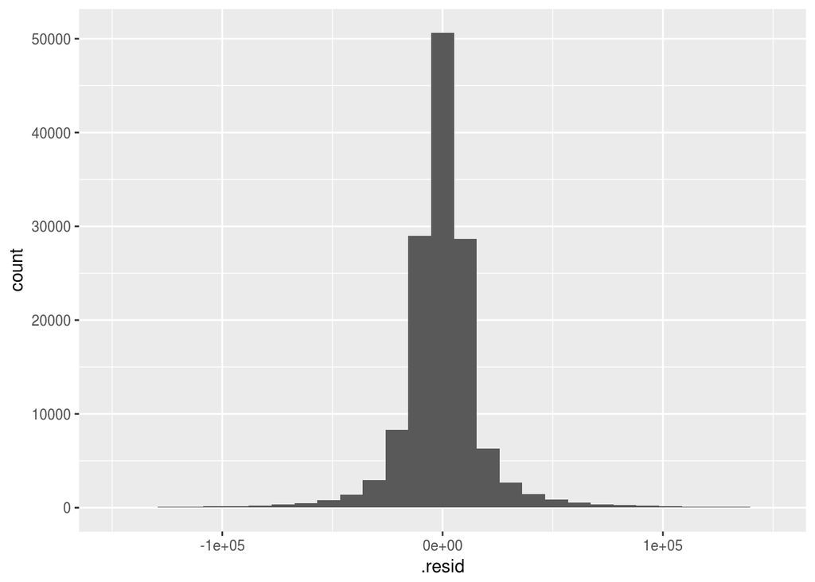

```r
ggplot(mattsmodel_lm4, aes(x=.resid)) + geom_histogram() + xlim(-150000, 150000)
```

#### Constant variance

Make an appropriate plot to check for constant variance (homeskedasticity) for your top model. Don't remember what kind of plot to make? See my notes on residual analysis or any intro stats book.

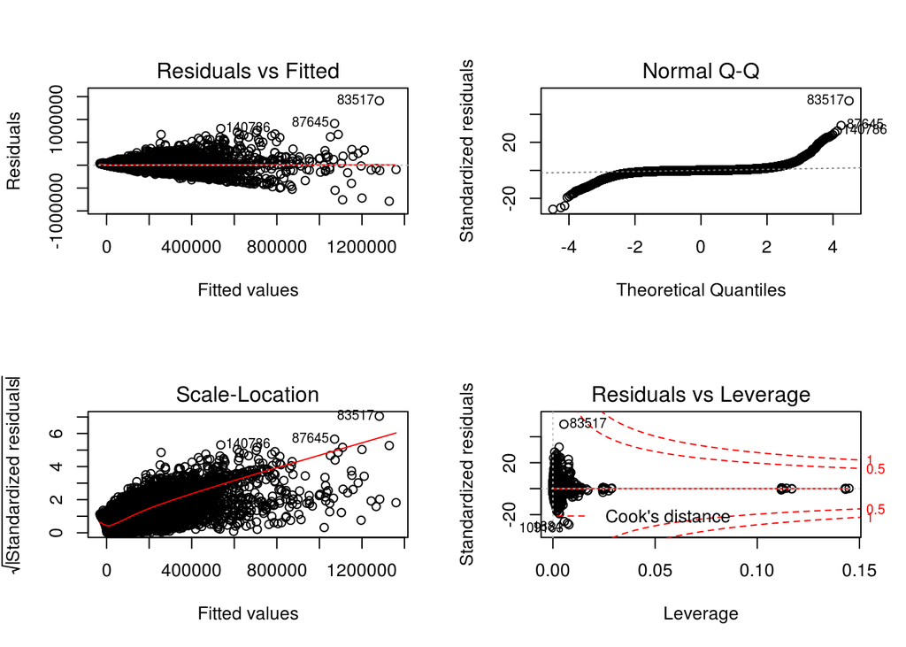

```r
#code from r-bloggers
par(mfrow=c(2,2))
plot(mattsmodel_lm2)
```

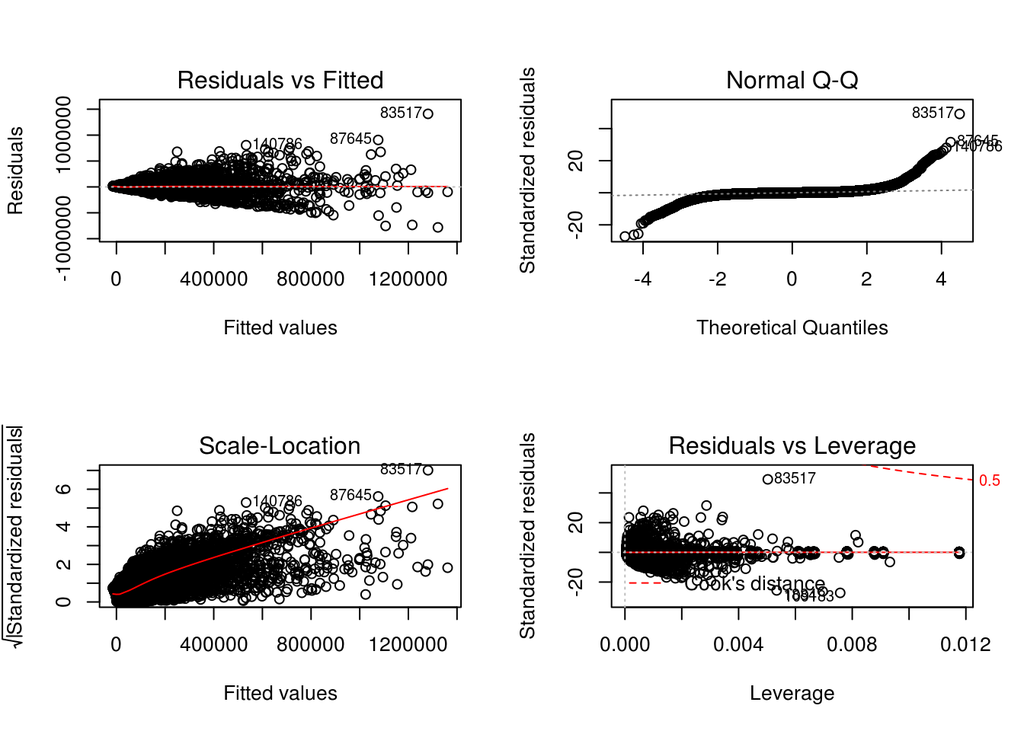

```r
par(mfrow=c(2,2))
plot(mattsmodel_lm3)
```

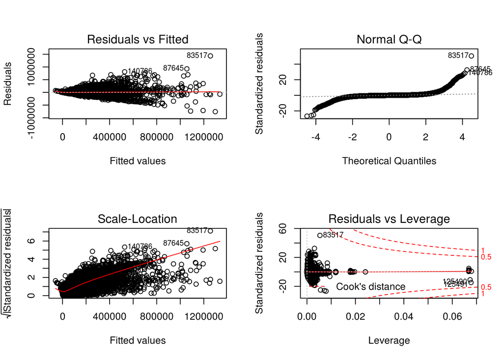

```r
par(mfrow=c(2,2))
plot(mattsmodel_lm4)
```

### Make predictions for the test dataset

For each of your top 3 models, make predictions for `ipd_test`.

```r
mattsmodel_lm2t <- (lm(Total_Charges ~ Total_Costs + Payment_Typology_1 + Patient_Disposition + Length_of_Stay + Hospital_County, data = ipd_test))

mattsmodel_lm3t <- (lm(Total_Charges ~ Total_Costs + Hospital_County + Length_of_Stay, data = ipd_test))

mattsmodel_lm4t <- (lm(Total_Charges ~ Total_Costs + Hospital_County + Length_of_Stay + Type_of_Admission + APR_Severity_of_Illness_Desc, data = ipd_test))

summary(mattsmodel_lm2t)
```

```
##
## Call:
## lm(formula = Total_Charges ~ Total_Costs + Payment_Typology_1 +
##     Patient_Disposition + Length_of_Stay + Hospital_County, data = ipd_test)
##
## Residuals:
##     Min      1Q  Median      3Q     Max
## -710512   -8176    -711    6565 1413531
##
## Coefficients:
##                                                            Estimate
## (Intercept)                                               3.810e+03
## Total_Costs                                               1.488e+00
## Payment_Typology_1Department of Corrections              -2.590e+04
## Payment_Typology_1Federal/State/Local/VA                 -4.127e+03
## Payment_Typology_1Managed Care, Unspecified              -1.770e+03
## Payment_Typology_1Medicaid                               -5.175e+03
## Payment_Typology_1Medicare                               -2.895e+03
## Payment_Typology_1Miscellaneous/Other                    -3.540e+03
## Payment_Typology_1Private Health Insurance               -2.135e+02
## Payment_Typology_1Self-Pay                               -2.301e+04
## Payment_Typology_1Unknown                                -5.288e+03
## Patient_DispositionCancer Center or Children's Hospital   3.270e+04
## Patient_DispositionCourt/Law Enforcement                  2.809e+04
## Patient_DispositionCritical Access Hospital               3.628e+03
## Patient_DispositionExpired                                9.117e+03
## Patient_DispositionFacility w/ Custodial/Supportive Care  1.009e+03
## Patient_DispositionFederal Health Care Facility           7.745e+03
## Patient_DispositionHome or Self Care                      3.051e+03
## Patient_DispositionHome w/ Home Health Services           4.501e+03
## Patient_DispositionHosp Basd Medicare Approved Swing Bed -2.470e+03
## Patient_DispositionHospice - Home                         6.250e+02
## Patient_DispositionHospice - Medical Facility             3.553e+03
## Patient_DispositionInpatient Rehabilitation Facility      8.761e+03
## Patient_DispositionLeft Against Medical Advice            2.362e+03
## Patient_DispositionMedicaid Cert Nursing Facility         5.295e+03
## Patient_DispositionMedicare Cert Long Term Care Hospital  8.735e+03
## Patient_DispositionPsychiatric Hospital or Unit of Hosp   2.190e+03
## Patient_DispositionShort-term Hospital                    1.584e+03
## Patient_DispositionSkilled Nursing Home                   3.904e+03
```

[output cut: 309 more lines]

```
## Hospital_CountySuffolk                                   ***
## Hospital_CountySullivan
## Hospital_CountyTompkins                                  ***
## Hospital_CountyUlster
## Hospital_CountyWarren                                    ***
## Hospital_CountyWayne                                     ***
## Hospital_CountyWestchester                               ***
## Hospital_CountyWyoming                                   ***
## Hospital_CountyYates                                     ***
## ---
## Signif. codes:  0 '***' 0.001 '**' 0.01 '*' 0.05 '.' 0.1 ' ' 1
##
## Residual standard error: 28470 on 58766 degrees of freedom
## Multiple R-squared:  0.7922, Adjusted R-squared:  0.7919
## F-statistic:  2636 on 85 and 58766 DF,  p-value: < 2.2e-16
```

```r
summary(mattsmodel_lm3t)
```

```
##
## Call:
## lm(formula = Total_Charges ~ Total_Costs + Hospital_County +
##     Length_of_Stay, data = ipd_test)
##
## Residuals:
##     Min      1Q  Median      3Q     Max
## -714646   -8023    -483    6433 1418775
##
## Coefficients:
##                              Estimate Std. Error t value Pr(>|t|)
## (Intercept)                 4.068e+03  7.363e+02   5.525 3.31e-08 ***
## Total_Costs                 1.478e+00  8.052e-03 183.521  < 2e-16 ***
## Hospital_CountyAllegany    -1.870e+04  2.712e+03  -6.895 5.43e-12 ***
## Hospital_CountyBronx       -5.690e+03  8.174e+02  -6.961 3.41e-12 ***
## Hospital_CountyBroome      -1.067e+04  1.263e+03  -8.447  < 2e-16 ***
## Hospital_CountyCattaraugus -1.512e+04  2.078e+03  -7.277 3.46e-13 ***
## Hospital_CountyCayuga      -1.368e+04  1.993e+03  -6.864 6.77e-12 ***
## Hospital_CountyChautauqua  -2.127e+04  1.710e+03 -12.442  < 2e-16 ***
## Hospital_CountyChemung     -9.359e+03  1.563e+03  -5.990 2.12e-09 ***
## Hospital_CountyChenango    -5.298e+03  3.751e+03  -1.413 0.157769
## Hospital_CountyClinton     -1.016e+04  1.666e+03  -6.102 1.06e-09 ***
## Hospital_CountyColumbia    -1.390e+04  2.011e+03  -6.913 4.79e-12 ***
## Hospital_CountyCortland    -1.793e+04  2.149e+03  -8.342  < 2e-16 ***
## Hospital_CountyDelaware    -1.592e+04  3.665e+03  -4.345 1.40e-05 ***
## Hospital_CountyDutchess     5.331e+03  1.151e+03   4.630 3.67e-06 ***
## Hospital_CountyErie        -9.526e+03  9.052e+02 -10.523  < 2e-16 ***
## Hospital_CountyEssex       -2.011e+04  4.845e+03  -4.151 3.31e-05 ***
## Hospital_CountyFranklin    -1.648e+04  2.744e+03  -6.005 1.92e-09 ***
## Hospital_CountyFulton      -7.043e+03  2.671e+03  -2.636 0.008383 **
## Hospital_CountyGenesee     -1.039e+04  3.022e+03  -3.439 0.000584 ***
## Hospital_CountyHerkimer    -1.573e+04  3.219e+03  -4.887 1.03e-06 ***
## Hospital_CountyJefferson   -1.004e+04  1.941e+03  -5.174 2.30e-07 ***
## Hospital_CountyKings       -9.959e+03  8.162e+02 -12.202  < 2e-16 ***
## Hospital_CountyLewis       -1.805e+04  3.843e+03  -4.697 2.65e-06 ***
## Hospital_CountyLivingston  -1.448e+04  2.671e+03  -5.419 6.02e-08 ***
## Hospital_CountyMadison     -1.129e+04  2.203e+03  -5.125 2.98e-07 ***
## Hospital_CountyManhattan    3.955e+03  8.107e+02   4.878 1.07e-06 ***
## Hospital_CountyMonroe      -1.622e+04  9.440e+02 -17.186  < 2e-16 ***
## Hospital_CountyMontgomery  -1.428e+04  2.154e+03  -6.631 3.35e-11 ***
```

[output cut: 21 more lines]

```
## Hospital_CountySullivan    -1.790e+03  2.605e+03  -0.687 0.491918
## Hospital_CountyTompkins    -2.057e+04  2.596e+03  -7.925 2.32e-15 ***
## Hospital_CountyUlster      -3.863e+02  1.696e+03  -0.228 0.819828
## Hospital_CountyWarren      -8.204e+03  1.457e+03  -5.629 1.82e-08 ***
## Hospital_CountyWayne       -9.791e+03  2.291e+03  -4.274 1.93e-05 ***
## Hospital_CountyWestchester  3.631e+03  9.154e+02   3.966 7.30e-05 ***
## Hospital_CountyWyoming     -2.378e+04  2.722e+03  -8.734  < 2e-16 ***
## Hospital_CountyYates       -2.069e+04  4.442e+03  -4.657 3.21e-06 ***
## Length_of_Stay              3.038e+03  3.003e+01 101.177  < 2e-16 ***
## ---
## Signif. codes:  0 '***' 0.001 '**' 0.01 '*' 0.05 '.' 0.1 ' ' 1
##
## Residual standard error: 28730 on 58793 degrees of freedom
## Multiple R-squared:  0.7883, Adjusted R-squared:  0.7881
## F-statistic:  3775 on 58 and 58793 DF,  p-value: < 2.2e-16
```

```r
summary(mattsmodel_lm4t)
```

```
##
## Call:
## lm(formula = Total_Charges ~ Total_Costs + Hospital_County +
##     Length_of_Stay + Type_of_Admission + APR_Severity_of_Illness_Desc,
##     data = ipd_test)
##
## Residuals:
##     Min      1Q  Median      3Q     Max
## -683757   -7976    -224    6890 1441063
##
## Coefficients:
##                                        Estimate Std. Error t value
## (Intercept)                           2.219e+04  9.725e+02  22.812
## Total_Costs                           1.441e+00  8.065e-03 178.712
## Hospital_CountyAllegany              -1.769e+04  2.688e+03  -6.579
## Hospital_CountyBronx                 -3.759e+03  8.148e+02  -4.613
## Hospital_CountyBroome                -1.041e+04  1.253e+03  -8.315
## Hospital_CountyCattaraugus           -1.529e+04  2.059e+03  -7.427
## Hospital_CountyCayuga                -1.363e+04  1.975e+03  -6.903
## Hospital_CountyChautauqua            -2.021e+04  1.695e+03 -11.925
## Hospital_CountyChemung               -9.188e+03  1.554e+03  -5.911
## Hospital_CountyChenango              -4.313e+03  3.715e+03  -1.161
## Hospital_CountyClinton               -9.359e+03  1.654e+03  -5.657
## Hospital_CountyColumbia              -1.170e+04  1.994e+03  -5.868
## Hospital_CountyCortland              -1.690e+04  2.130e+03  -7.933
## Hospital_CountyDelaware              -1.430e+04  3.631e+03  -3.937
## Hospital_CountyDutchess               5.651e+03  1.142e+03   4.949
## Hospital_CountyErie                  -9.555e+03  8.985e+02 -10.635
## Hospital_CountyEssex                 -1.730e+04  4.799e+03  -3.605
## Hospital_CountyFranklin              -1.624e+04  2.718e+03  -5.975
## Hospital_CountyFulton                -6.035e+03  2.646e+03  -2.281
## Hospital_CountyGenesee               -9.359e+03  2.994e+03  -3.126
## Hospital_CountyHerkimer              -1.503e+04  3.195e+03  -4.704
## Hospital_CountyJefferson             -8.843e+03  1.924e+03  -4.596
## Hospital_CountyKings                 -8.343e+03  8.130e+02 -10.262
## Hospital_CountyLewis                 -1.606e+04  3.807e+03  -4.219
## Hospital_CountyLivingston            -1.252e+04  2.648e+03  -4.730
## Hospital_CountyMadison               -1.023e+04  2.183e+03  -4.688
## Hospital_CountyManhattan              4.538e+03  8.050e+02   5.637
## Hospital_CountyMonroe                -1.578e+04  9.371e+02 -16.835
```

[output cut: 98 more lines]

```
## Length_of_Stay                        < 2e-16 ***
## Type_of_AdmissionEmergency            < 2e-16 ***
## Type_of_AdmissionNewborn             0.059768 .
## Type_of_AdmissionNot Available       0.150478
## Type_of_AdmissionTrauma              0.063909 .
## Type_of_AdmissionUrgent              0.000317 ***
## APR_Severity_of_Illness_DescMajor     < 2e-16 ***
## APR_Severity_of_Illness_DescMinor     < 2e-16 ***
## APR_Severity_of_Illness_DescModerate  < 2e-16 ***
## ---
## Signif. codes:  0 '***' 0.001 '**' 0.01 '*' 0.05 '.' 0.1 ' ' 1
##
## Residual standard error: 28450 on 58785 degrees of freedom
## Multiple R-squared:  0.7924, Adjusted R-squared:  0.7922
## F-statistic:  3400 on 66 and 58785 DF,  p-value: < 2.2e-16
```

### Evaluate the predictions

Compute the MAD for each of the three models' predictions on the test data.

HINT: Obviously you can't use the residuals (or errors) directly but will have to compute them. They are simply the difference between the actual values and your predicted values.

So, for the model I mentioned earlier that had a MAD of 7270.340 for the training data, the MAD on the test data was 7335.559. Notice that MAD for test is higher than MAD for train.

```r
residuals1 <-ipd_test$Total_Charges - mattsmodel_lm2t$fitted.values
residuals2 <-ipd_test$Total_Charges - mattsmodel_lm3t$fitted.values
residuals3 <-ipd_test$Total_Charges - mattsmodel_lm4t$fitted.values


MADtest1 <- median(abs(residuals1))
MADtest2 <- median(abs(residuals2))
MADtest3 <- median(abs(residuals3))

MADtest1
```

```
## [1] 7365.883
```

```r
MADtest2
```

```
## [1] 7181.357
```

```r
MADtest3
```

```
## [1] 7371.107
```

**QUESTION:** Do you think it's typical that MAD for test would be higher than MAD for train? Why or why not?

Yes, it seems logical that models would preform worse on data it hasn't "seen". There could be structual patterns or other forms of statistical bias present in the training data that make the testing data harder to predict. Outliers in the training data set make it harder to predict values for the testing data.

**QUESTION:** Which of your top 3 models had the lowest MAD for the test data?

The third model which was the simplest out of all of the models preformed best on the testing data.

**QUESTION:** How do the MAD values for the test data compare to the MAD values for the training data?

The mad values for the test data seems to uniformally be higher on all of the models. If I tried my other two models on the test data I am sure that thier MAD scores would also be higher.

Finally, create some sort of plot which shows the MAD values for both train and test for your top 3 models. One plot.

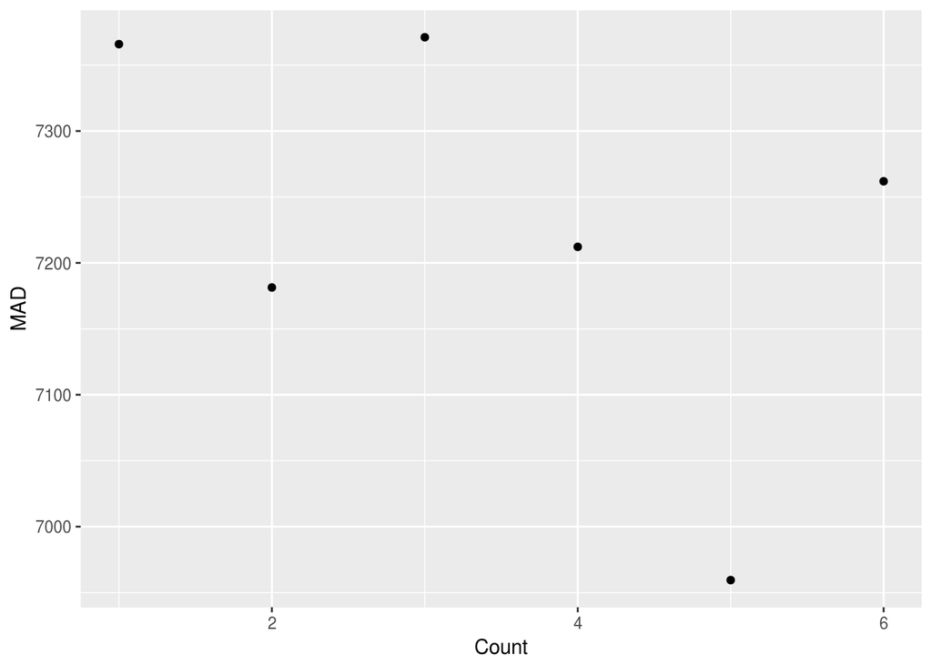

```r
MADtrain1 <- median(abs(mattsmodel_lm2$residuals))
MADtrain2 <- median(abs(mattsmodel_lm3$residuals))
MADtrain3 <- median(abs(mattsmodel_lm4$residuals))


MAD <- c(MADtest1, MADtest2, MADtest3, MADtrain1, MADtrain2, MADtrain3)

qplot(seq_along(MAD), MAD) + xlab("Count")
```

```r
#barplot(MAD, main =  "MAD values for both test and train predictions")
```

### Your top model

Show your top performing model and discuss whether the model appears to make sense in terms of the variables included. Why did you choose the variables you did?

lm(Total_Charges ~ Total_Costs + Hospital_County + Length_of_Stay, data = ipd_train)

Total costs have a large and disproportionate effect on hospital charges, which I was able to observe in the plot I made. The location the hospital was situated in as well as that areas economic advantages or disadvantages would have an effect on the amount charged. Lastly length of stay would have a strong effect on the amount charged especially as that value got larger.

It will be interesting to compare the best models that everyone finds.

Later we'll learn more techniques that will likely allow us to beat simple linear models.